# Change Point Analysis

# Input Data

## Packages

**Note**

I used the `changepoint` package to test for a change in mean in the data set. The `cpt.mean()` package tested this using the AMOC method, which was suitable for data with a single change point.

```r
library(tidyverse)
if(require("changepoint")){
    print("changepoint is loaded correctly")
} else {
    print("trying to install changepoint")
    install.packages("changepoint")
    if(require(changepoint)){
        print("changepoint installed and loaded")
    } else {
        stop("could not install changepoint")
    }
}
```

```
Successfully loaded changepoint package version 2.2.4
 See NEWS for details of changes.
```

```
[1] "changepoint is loaded correctly"
```

```r
library(here)
```

## Plot Data

```r
files <-list.files(path="../plots/data",full.names=T)
df <- files |> map_dfr(read_csv)
```

## Picture details

```r
pic_details <- read_csv("../plots/picture_details.csv") |>
  rename(picid = lineup_id) |>
  select(picid,theta,cpLoc,sigma,version)
```

## Identification Probabilities

```r
all_data_clean <- read_csv(here("data", "lineup_clean.csv")) |>
  mutate(across(lineup_id:version, ~ as.factor(.x)),
         direction = fct_relevel(direction, c("Positive", "Negative"))
         )
```

# Change Point Analysis

**Note**

Only analyzed target plots.

```r
cploc_CPD <- function(x){
  cpt.mean(x, method="AMOC",class=FALSE)->cploc
  cploc |> as.numeric()
}

mean_diff <- function(x){
  cpt.mean(x, method="AMOC",class=TRUE)->cploc
  param.est(cploc)$mean |> diff() |> as.numeric()
}
cp_test_results <- df |>
  filter(panel=="target") |>
  group_by(picid) |>
  summarize(change_point = cploc_CPD(value)[1],
            confvalue = cploc_CPD(value)[2] |> round(4)#,
            # shift_size = mean_diff(value) |> round(1)
) |>
  mutate(CP_detected = case_when(change_point==30 | confvalue <0.90~"No",
                                 .default="Yes")) |>
ungroup()

cp_test_results |> left_join(pic_details,by="picid") |>
  # relocate(shift_size,.before= theta) |>
  mutate(visual_changepoint = round(30*cpLoc,2)) |>
  relocate(visual_changepoint,.before=change_point) -> cp_test_results

cp_test_results |>
DT::datatable()
```

**1**

Outputs a vector with length 2: estimated change point location and “confidence value”.

**2**

If the change point is set at 30, this means there was no detected change point. If the confidence value < 0.90 when the change point is less than 30, this means the algorithm is not too sure that we have a change point.

**3**

Joining the target plot distribution details with the change point results.

|  | picid | visual_changepoint | change_point | confvalue | CP_detected | theta | cpLoc | sigma | version |
| --- | --- | --- | --- | --- | --- | --- | --- | --- | --- |
| 1 | 011cb242b0375a3557b47f6a65635b28 | 10 | 30 | 0.0002 | No | 0 | 0.333333333 | 2 | A |
| 2 | 09ad4e81eeb88419b25ec0adc6467432 | 10 | 30 | 0 | No | 1 | 0.333333333 | 2 | B |
| 3 | 0da5395eecdbf0d61fe3ad150f174474 | 10 | 10 | 0.9096 | Yes | -5 | 0.333333333 | 2 | B |
| 4 | 0f1e3b5dac62ff2545207edfcf5e8454 | 10 | 10 | 0.9738 | Yes | -5 | 0.333333333 | 1 | B |
| 5 | 0f61d71b2f26894dd0c8ab8d7faf80d3 | 20 | 20 | 0.9915 | Yes | 5 | 0.666666667 | 2 | A |
| 6 | 122f70504fb76130d513d1b9d2acf8c7 | 20 | 30 | 0 | No | -1 | 0.666666667 | 1 | B |
| 7 | 17687110cdfea87d7640463ce9a79226 | 15 | 15 | 0.9963 | Yes | -5 | 0.5 | 1 | B |
| 8 | 1c28b70622bb31d832af452e6fdab8d9 | 15 | 30 | 0.0001 | No | -1 | 0.5 | 1 | A |
| 9 | 1d5b6e2f0bade407b23cc7e72f87371b | 10 | 10 | 0.9619 | Yes | 5 | 0.333333333 | 1 | B |
| 10 | 1f53122367f2a2eb80fdc74347a7e1d1 | 10 | 9 | 0.0246 | No | -1 | 0.333333333 | 1 | B |

[output cut: 74 more lines]

**Warning**

Confidence value is not the same as the confidence level in a confidence level interval. It’s basically telling us if the algorithm is sure that there is indeed a change point there.

## Confidence Value Plots

```r
confvalue_plt <- cp_test_results |>
filter(theta!=0) |>
mutate(Location=case_when(visual_changepoint == 10~"Early",
                visual_changepoint == 15~"Middle",
                visual_changepoint == 20~"Late"),
          MagDir = case_when(theta ==-5 ~"- High", theta ==5 ~"+ High", theta==3~ "+ Medium", theta==-3~ "- Medium", theta == 1~" + Low", theta == - 1~" - Low"),
          Variance = case_when(sigma==1~"Low",sigma==2~"High"))  |>
mutate(MagDir = factor(MagDir, levels=c("- High","- Medium"," - Low"," + Low","+ Medium","+ High")),
Variance = factor(Variance,levels=c("Low","High")),
Location = factor(Location,levels=c("Early","Middle","Late"))) |>
dplyr::select(confvalue,CP_detected,Location,MagDir,Variance,version)

confvalue_plt |>
dplyr::select(-CP_detected) |>
group_by(MagDir, Variance,Location) |>
summarize(avg_confvalue = mean(confvalue)) |>
ungroup() |>
ggplot(aes(y=MagDir,x=avg_confvalue)) +
facet_grid(Location~ Variance,labeller=label_both) +
geom_bar(stat="identity") +
theme_bw() +
labs(y = "Theta \n(Mean Shift + Direction)",
       x = "Confidence Value",
       title = "Change Point Analysis (changepoint::cpt.mean()) confidence values"
       )
```

**1**

taking out Rorschach plots

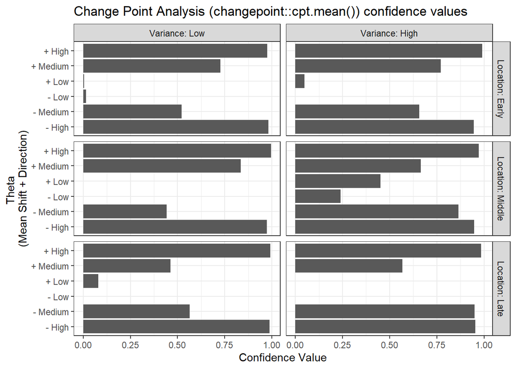

**Warning**

I don’t know why the confidence value is peaking at 2! It’s supposed to all be below 1.

**FIXED: It added the two confidence value from the 2 versions.**

**Note**

This looks similar to the identification probability plots.

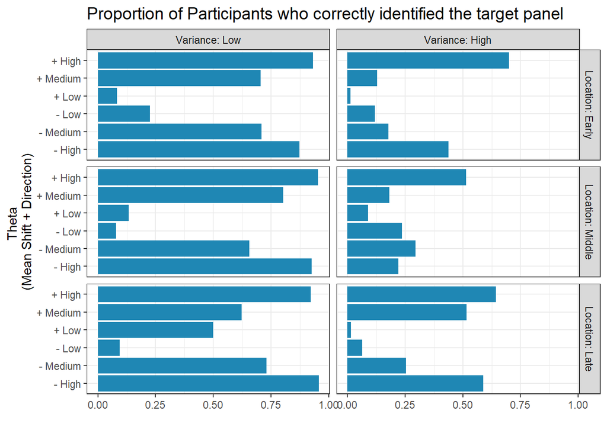

```r
all_data_clean |>
  select(participant_id, version, cpLoc, sigma, theta, correct, response_no, obs_plot_location) |>
   mutate(Location = fct_recode(cpLoc,
                            "Early" = "0.333333333",
                            "Middle" = "0.5",
                            "Late" = "0.666666667"
                            ),
          MagDir = case_when(theta ==-5 ~"- High", theta ==5 ~"+ High", theta==3~ "+ Medium", theta==-3~ "- Medium", theta == 1~" + Low", theta == - 1~" - Low"),
          Variance = case_when(sigma==1~"Low",sigma==2~"High"))  |>
mutate(MagDir = factor(MagDir, levels=c("- High","- Medium"," - Low"," + Low","+ Medium","+ High")),
Variance = factor(Variance,levels=c("Low","High")),
Location = factor(Location,levels=c("Early","Middle","Late"))) |>
  group_by(Location, Variance, MagDir) |>
  summarize(prop_correct = sum(correct)/n())|>
  ggplot(aes(y = MagDir,
             x = prop_correct)
         ) +
  geom_bar(stat = "identity",
           fill = "#1F87B4") +
  facet_grid(Location ~ Variance,
             labeller = label_both) +
  theme_bw() +
  labs(y = "Theta \n(Mean Shift + Direction)",
       x = "",
       title = "Proportion of Participants who correctly identified the target panel"
       ) +
  theme(plot.title = ggtext::element_markdown(size = 14)
        )
```

## Change Point with Visual Inference

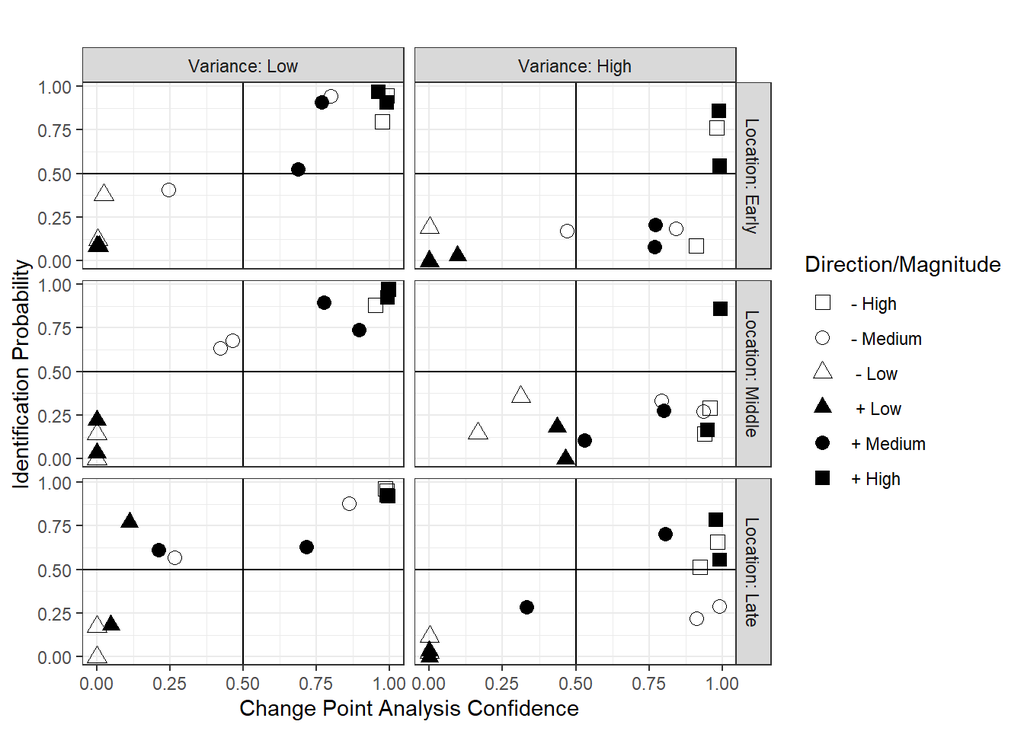

```r
prop_correct_df <- all_data_clean |>
  select(participant_id, version, cpLoc, sigma, theta, correct, response_no, obs_plot_location) |>
   mutate(Location = fct_recode(cpLoc,
                            "Early" = "0.333333333",
                            "Middle" = "0.5",
                            "Late" = "0.666666667"
                            ),
          MagDir = case_when(theta ==-5 ~"- High", theta ==5 ~"+ High", theta==3~ "+ Medium", theta==-3~ "- Medium", theta == 1~" + Low", theta == - 1~" - Low"),
          Variance = case_when(sigma==1~"Low",sigma==2~"High")) |>
mutate(MagDir = factor(MagDir, levels=c("- High","- Medium"," - Low"," + Low","+ Medium","+ High")),
Variance = factor(Variance,levels=c("Low","High")),
Location = factor(Location,levels=c("Early","Middle","Late"))) |>
  group_by(version, Location, Variance, MagDir) |>
  summarize(prop_correct = sum(correct)/n())
confvalue_plt |>
left_join(prop_correct_df,by=c("MagDir","Variance","Location","version")) ->comp

comp |>
ggplot(aes(x=confvalue,y=prop_correct)) +
# geom_text(aes(label=MagDir))+
geom_point(aes(shape=MagDir),size=3) +
#geom_label(aes(label=Location),nudge_x=0.1)+
geom_hline(yintercept=0.5) +
geom_vline(xintercept=0.5) +
facet_grid(Location~Variance,labeller=label_both)+
theme_bw() +
scale_shape_manual(name="Direction/Magnitude",
                    values=c(0,1,2,17,16,15))+
labs(x = "Change Point Analysis Confidence",
       y = "Identification Probability",
       title = ""
       )
```

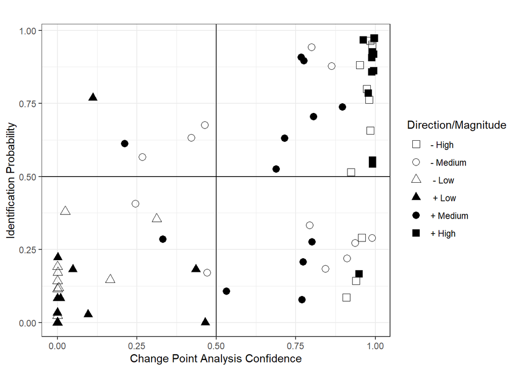

```r
ggsave("changepoint_cplocXvariance.png",dpi=300, width=6, height=8, units="in")

comp |>
ggplot(aes(x=confvalue,y=prop_correct)) +
# geom_text(aes(label=MagDir))+
geom_point(aes(shape=MagDir),size=3) +
#geom_label(aes(label=Location),nudge_x=0.1)+
geom_hline(yintercept=0.5) +
geom_vline(xintercept=0.5) +
# facet_grid(Location~Variance,labeller=label_both)+
theme_bw() +
scale_shape_manual(name="Direction/Magnitude",values=c(0,1,2,17,16,15))+
labs(x = "Change Point Analysis Confidence",
       y = "Identification Probability",
       title = ""
       )
```

```r
ggsave("changepoint.png",dpi=300, width=6, height=8, units="in")
```